# CoDaCoRe Tutorial on Chron’s Disease Data

Elliott Gordon-Rodriguez

3/12/2021

## The basics

We assume a working installation of `codacore`, as well as the `selbal` package ([link](https://github.com/UVic-omics/selbal/blob/master/vignettes/vignette.Rmd)), from which we will borrow the Crohn disease data.

```r
library("codacore")
library("selbal")
data("Crohn")
x <- Crohn[, -ncol(Crohn)]
y <- Crohn[, ncol(Crohn)]
```

Our goal is to predict disease status from microbe counts. Our input variable consists of the abundance of 48 microbial species in 975 samples.

```r
dim(x)
```

```
## [1] 975  48
```

The output variable is a binary indicator.

```r
table(y)
```

```
## y
##  CD  no
## 662 313
```

Prior to fitting CoDaCoRe, we must impute any counts of zero in our input variable (a standard pre-processing step for ratio-based and CoDa methods).

```r
x <- x + 1
```

Next, we split our data into a training and a test set (to keep things simple we do this naively at random, though in practice stratified sampling is preferable).

```r
# For reproducibility, we set a random seed (including in TensorFlow, used by codacore)
set.seed(0); library(tensorflow); tf$random$set_seed(0)
trainIndex <- sample(1:nrow(x), 0.8 * nrow(x))
xTrain <- x[trainIndex,]
yTrain <- y[trainIndex]
```

Now we are ready to fit CoDaCoRe. Notice the fast runtime (as compared to, for example, `selbal.cv`).

```r
model = codacore(
  xTrain,
  yTrain,
  logRatioType = 'balances', # can also use 'amalgamations'
  lambda = 1                 # regularization parameter (1 corresponds to "1SE rule")
)
```

Next we can check the learned output of the model: what inputs were included in the learned log-ratios, how strongly associated they are to the response, and how well they classified the data.

```r
print(model)
```

```
##
## Number of log-ratios found: 2
## ***
## Log-ratio rank 1
## Numerator: g__Roseburia
## Denominator: g__Dialister
## Slope: 0.2642687
## AUC: 0.7306284
## ***
## Log-ratio rank 2
## Numerator: g__Parabacteroides f__Peptostreptococcaceae_g__ g__Bacteroides g__Faecalibacterium g__Roseburia g__Lachnospira o__Clostridiales_g__ f__Rikenellaceae_g__ g__Bilophila
## Denominator: g__Eggerthella g__Dialister g__Streptococcus g__Aggregatibacter
## Slope: 0.387607
## AUC: 0.7788797
```

The most predictive ratio identified by codacore is g__Roseburia / g__Dialister, which can be visualized with the `plot` function.

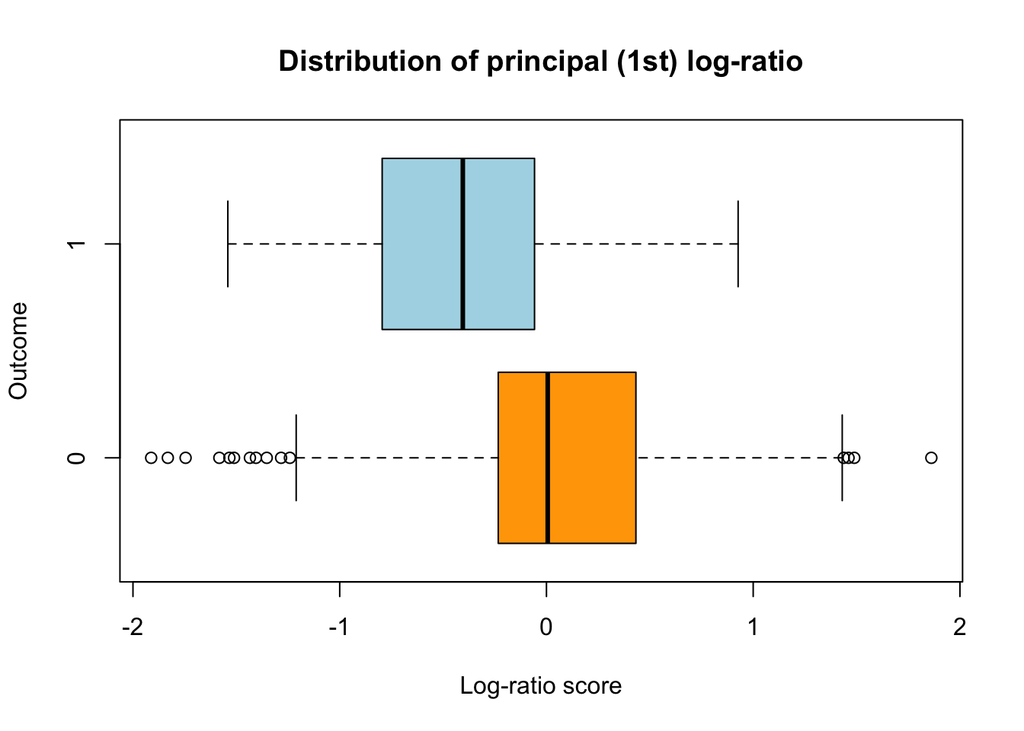

```r
plot(model)
```

We can also use our trained model to classify new samples.

```r
xTest <- x[-trainIndex,]
yTest <- y[-trainIndex]
yHat = predict(model, xTest, logits=F)
# Convert probabilities into a binary class
failure = yHat < 0.5
success = yHat >= 0.5
yHat[failure] = levels(y)[1]
yHat[success] = levels(y)[2]
cat("Classification accuracy on test set =", round(mean(yHat == yTest), 2))
```

```
## Classification accuracy on test set = 0.75
```